# data_science_project

# “Forecasting State-wise Unemployment Using Linear Regression”

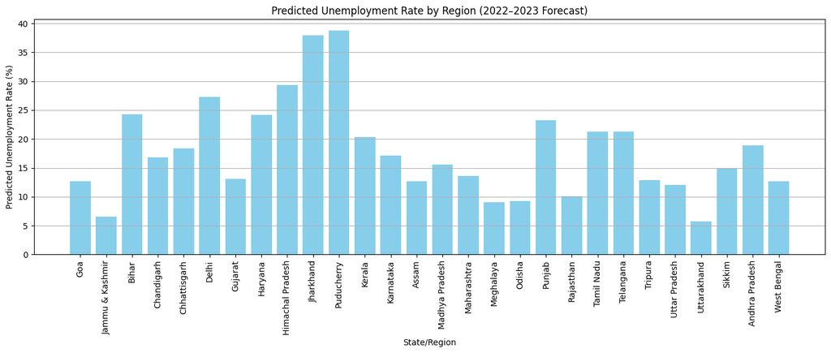

```python
import pandas as pd
import matplotlib.pyplot as plt
from sklearn.model_selection import train_test_split
from sklearn.linear_model import LinearRegression
from sklearn.preprocessing import LabelEncoder
from sklearn.metrics import mean_squared_error, r2_score

unemployement_data = pd.read_csv("/content/Unemployment in India.csv")

# Clean column names
unemployement_data.columns = unemployement_data.columns.str.strip()

# Drop rows with missing values
unemployement_data.dropna(subset=[
    'Estimated Unemployment Rate (%)',
    'Estimated Labour Participation Rate (%)',
    'Area',
    'Region'
], inplace=True)

# Create previous rate column
unemployement_data['Previous Rate'] = unemployement_data['Estimated Unemployment Rate (%)'].shift(1)
unemployement_data.dropna(inplace=True)

# Label encoding
le_area = LabelEncoder()
unemployement_data['Area'] = le_area.fit_transform(unemployement_data['Area'])

le_region = LabelEncoder()
unemployement_data['Region'] = le_region.fit_transform(unemployement_data['Region'])

# Define features and target
X = unemployement_data[['Previous Rate', 'Estimated Labour Participation Rate (%)', 'Area', 'Region']]
y = unemployement_data['Estimated Unemployment Rate (%)']

# Train-test split
X_train, X_test, y_train, y_test = train_test_split(X, y, test_size=0.2, random_state=42)

# Train model
model = LinearRegression()
model.fit(X_train, y_train)

# Prepare future data for all states using their latest entries
unemployement_data['Date'] = pd.to_datetime(unemployement_data['Date'])
latest_data = unemployement_data.sort_values('Date').groupby('Region').tail(1)

# Predict using the trained model
X_future = latest_data[['Previous Rate', 'Estimated Labour Participation Rate (%)', 'Area', 'Region']]
future_predictions = model.predict(X_future)

# Add predictions back
latest_data['Predicted Unemployment Rate (%)'] = future_predictions
latest_data['Region'] = le_region.inverse_transform(latest_data['Region'])
latest_data['Area'] = le_area.inverse_transform(latest_data['Area'])

# Plotting
plt.figure(figsize=(14, 6))
plt.bar(latest_data['Region'], latest_data['Predicted Unemployment Rate (%)'], color='skyblue')
plt.xticks(rotation=90)
plt.xlabel("State/Region")
plt.ylabel("Predicted Unemployment Rate (%)")
plt.title("Predicted Unemployment Rate by Region (2022–2023 Forecast)")
plt.tight_layout()
plt.grid(axis='y')
plt.show()
```

Here I’ve used linear regression to predict the unemployment rate for each state using features like the last known rate, labour participation rate, and area type (Urban/Rural). The model helped me identify that Puducherry has the highest predicted unemployment rate, possibly due to its small population and limited industrial activity. Even though it's classified as urban, there may be fewer job opportunities compared to the number of job seekers, causing high competition and higher unemployment.

This trend is clearly visible in the bar graph, where Puducherry's predicted rate stands out among other regions.